# Key Risk Factors of Heart Disease in 2020

Team One

April 4, 2022

According to the Center for Disease Control and Prevention (CDC), cardiovascular or heart diseases account for 1 in every 4 deaths in the United States annually. The estimated costs to the nation’s economy amount to about $363 billion annually, which include hospitalizations, after services health care needs as well as lost productivity due to death and disability (SS Virani, 2021). The CDC also states that given the lifestyle habits of an average American, about half of the population (47%) are reported to have “1 of the 3 key risk factors for heart disease: high blood pressure, high cholesterol, and smoking”. However, the risk factors for developing heart diseases are vast and diverse and tend to vary between most racial and ethnic groups in the United States.

Therefore, there is an immediate need to detect the major risk factors early on, so that a wellness-oriented healthcare system can be instituted. Ideally, such a system would assess the intensity of the risk factors (compared to a baseline) and focus efforts on preventing the occurrence of developing heart diseases in the first place rather than minimizing second occurrences (Liau et al, 2010; Giampaoli et al, 2005 ).

The beginnings of the current understanding of the interconnected role of risk factors was first discussed in the Framingham Heart Study. Started in 1948, the study’s original goal was “ to identify common factors or characteristics that contribute to cardiovascular disease” (Hong 2018). However, today the FHS has morphed into a multigenerational study gathering genetic information that help analyze family patterns of certain diseases, including cardiovascular ailments (National Heart, Lung and Blood Institute). Jumping off from this, current research in the field has focused on using precision medicine algorithms along with computational development technology to assess a patient’s likelihood of developing heart disease given certain lifestyle factors. Most of the studies have focused largely on Caucasian individuals as a sample and indicating that there is a gap in the usefulness of current risk assessment tools working for individuals of differenet races.

In this paper, we aim to understand the different risk factors that affect the occurrence of heart diseases in the US population, so that we may be able to see some of the intermingling between different risk factors.

# Description of Dataset

The original data set can be retrieved from the CDC’s Behavioral Risk Factor Surveillance System (BRFSS) annual health survey. The survey interviews over four hundred thousand individuals in the USA asking questions regarding the risk factors of heart disease. Conducted in 2020 (published on February 15, 2020), the original data set has been cleaned from its original 300 variables to 18 variables by Kamil Pytlak and can be accessed on Kaggle .

```r
# Lets load the appropriate libraries
library(tidyverse)
library(dplyr)
library(funModeling)
library(ezids)
library(ggplot2)
library(ggcorrplot)
library(corrr)
library(corrplot)

# Load the Data
heart <-read.csv("heart_2020_cleaned.csv")
nrow (heart)
```

[output not shown]

```r
# Descrpitive Statistics
status (heart)
```

```
##                          variable q_zeros p_zeros q_na p_na q_inf p_inf
## HeartDisease         HeartDisease       0   0.000    0    0     0     0
## BMI                           BMI       0   0.000    0    0     0     0
## Smoking                   Smoking       0   0.000    0    0     0     0
## AlcoholDrinking   AlcoholDrinking       0   0.000    0    0     0     0
## Stroke                     Stroke       0   0.000    0    0     0     0
## PhysicalHealth     PhysicalHealth  226589   0.709    0    0     0     0
## MentalHealth         MentalHealth  205401   0.642    0    0     0     0
## DiffWalking           DiffWalking       0   0.000    0    0     0     0
## Sex                           Sex       0   0.000    0    0     0     0
## AgeCategory           AgeCategory       0   0.000    0    0     0     0
## Race                         Race       0   0.000    0    0     0     0
## Diabetic                 Diabetic       0   0.000    0    0     0     0
## PhysicalActivity PhysicalActivity       0   0.000    0    0     0     0
## GenHealth               GenHealth       0   0.000    0    0     0     0
## SleepTime               SleepTime       0   0.000    0    0     0     0
## Asthma                     Asthma       0   0.000    0    0     0     0
## KidneyDisease       KidneyDisease       0   0.000    0    0     0     0
## SkinCancer             SkinCancer       0   0.000    0    0     0     0
##                       type unique
## HeartDisease     character      2
## BMI                numeric   3604
## Smoking          character      2
## AlcoholDrinking  character      2
## Stroke           character      2
## PhysicalHealth     integer     31
## MentalHealth       integer     31
## DiffWalking      character      2
## Sex              character      2
## AgeCategory      character     13
## Race             character      6
## Diabetic         character      4
## PhysicalActivity character      2
## GenHealth        character      5
## SleepTime          integer     24
## Asthma           character      2
## KidneyDisease    character      2
## SkinCancer       character      2
```

We can also see that there are no N/A values in our data set. This is not surprising given that our data was cleaned before being retrieved.

Below are the plots showing the means of our numerical variables. We can see that, on average, people with heart disease have a slightly higher BMI than those who don’t have heart disease. However, the biggest difference is the number of days that a respondent feels physically unwell. Respondents who have heart disease reported feeling physically unwell about 8 days per month, while healthy people felt unwell for only 3. Poor mental health in a 30 day period is slightly higher for people with heart disease, than for people without.

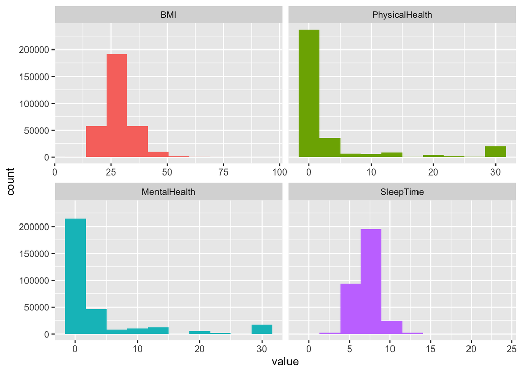

```r
# Finding the mean of numerical variables grouped by heart disease
plot_num(heart)
```

```r
heart %>%
  group_by(HeartDisease) %>%
  summarise_at(vars("BMI",
                    "PhysicalHealth",
                    "MentalHealth",
                    "SleepTime"), mean)
```

```
## # A tibble: 2 × 5
##   HeartDisease   BMI PhysicalHealth MentalHealth SleepTime
##   <chr>        <dbl>          <dbl>        <dbl>     <dbl>
## 1 No            28.2           2.96         3.83      7.09
## 2 Yes           29.4           7.81         4.64      7.14
```

```r
# Changing Diabetes bordeline and pregnancy categories to Yes/No

heart$Diabetic<- replace (heart$Diabetic, heart$Diabetic== "No, borderline diabetes" , "Yes")
heart$Diabetic[heart$Diabetic== "Yes (during pregnancy)"] <- "No"

# Changing all the categorical variables to numerical dummies

heart$HeartDisease<-ifelse(heart$HeartDisease=="Yes",1,0)
heart$Smoking<-ifelse(heart$Smoking=="Yes",1,0)
heart$AlcoholDrinking<-ifelse(heart$AlcoholDrinking=="Yes",1,0)
heart$Stroke<-ifelse(heart$Stroke=="Yes",1,0)
heart$DiffWalking<-ifelse(heart$DiffWalking=="Yes",1,0)
heart$PhysicalActivity<-ifelse(heart$PhysicalActivity=="Yes",1,0)
heart$KidneyDisease<-ifelse(heart$KidneyDisease=="Yes",1,0)
heart$SkinCancer<-ifelse(heart$SkinCancer=="Yes",1,0)
heart$Diabetic<-ifelse(heart$Diabetic=="Yes",1,0)
heart$Asthma<-ifelse(heart$Asthma=="Yes",1,0)
```

# Correlation Plots of All Variables

[figure not shown]

```r
 model.matrix(~0+., data=heart) %>%
     cor(use="pairwise.complete.obs") %>%
   ggcorrplot(show.diag = F, type="upper", lab=TRUE, lab_size=1)
```

## Gender and Lifestyle Factors

According to Noel Bairey Merz, MD, director of the Barbra Streisand Women’s Heart Center in the Smidt Heart Institute, women experience heart disease more severely than men. Meaning that even though men are more likely to suffer heart attacks, women are more likely to die from a heart attack than a man.

# Contingency Table for Sex & Heart Disease

[output not shown]

[figure not shown]

After sub-setting the data between male and female, we conducted a Welch’s t-test on the BMIs of both population subsets.

```r
# Subset Male & Female with and without Heart Disease
female <- subset(heart, Sex== "Female")
male  <- subset (heart, Sex == "Male")

# T-test of BMI between Genders
t.test(female$BMI, male$BMI)
```

```
##
##  Welch Two Sample t-test
##
## data:  female$BMI and male$BMI
## t = -15, df = 3e+05, p-value <2e-16
## alternative hypothesis: true difference in means is not equal to 0
## 95 percent confidence interval:
##  -0.387 -0.299
## sample estimates:
## mean of x mean of y
##      28.2      28.5
```

The p-value is less than 5% significance level, allowing us to reject the null hypothesis and conclude that the overall average BMI is different between the male and female populations. From the mean values, we see that men have a mean BMI of 28.50 while women have a BMI of 28.16. A difference of 0.34.

Next, we divided our data frame between men and women who do have heart disease. Once again assuming normality due to the large sample size, we conducted another Welch’s T-test to look at the mean BMI difference.